# Dave’s Homework 1 Analysis

Reading in the restaurant data with the arules package.

```r
library(arules)
menu <- read.transactions("../restaurantData.csv", sep = ",")
```

## Background

A restaurant owner has a core menu that has remained constant throughout the past two years, while many other dishes have rotated on and off the menu. The owner has prepared a dataset of all orders containing elements of that core menu in which the customer also ordered wine. The dataset has 3 columns: orderNumber which identifies each individual person’s order at a table, order which itemizes the order’s components, and type which provides the type of item in the order (takes one of 3 values: ‘Meat’, ‘Side’, ‘Wine’).

## Task

The restaurant owner would like to add wine suggestions to the menu next to each meat and analyze her customer ordering habits in general. She is also interested in showing a picture of a popular meal of hers in an ad in Gourmet Diner magazine. Your job is to address her interests and also to report anything else of interest in terms of customer ordering habits, all in a nice summary report that is complete but to the point.

#### Overview of the dataset

```r
str(menu)
```

```
## Formal class 'transactions' [package "arules"] with 3 slots
##   ..@ data       :Formal class 'ngCMatrix' [package "Matrix"] with 5 slots
##   .. .. ..@ i       : int [1:80049] 8509 8510 8517 361 8506 8515 361 8505 8507 361 ...
##   .. .. ..@ p       : int [1:26684] 0 3 6 9 12 15 18 21 24 27 ...
##   .. .. ..@ Dim     : int [1:2] 8519 26683
##   .. .. ..@ Dimnames:List of 2
##   .. .. .. ..$ : NULL
##   .. .. .. ..$ : NULL
##   .. .. ..@ factors : list()
##   ..@ itemInfo   :'data.frame':  8519 obs. of  1 variable:
##   .. ..$ labels: chr [1:8519] "10004" "10023" "10025" "10040" ...
##   ..@ itemsetInfo:'data.frame':  0 obs. of  0 variables
```

```r
summary(menu)
```

```
## transactions as itemMatrix in sparse format with
##  26683 rows (elements/itemsets/transactions) and
##  8519 columns (items) and a density of 0.000352154
##
## most frequent items:
##                 Meat                 Side                 Wine
##                 8894                 8894                 8894
##      Pork Tenderloin Cantina Pinot Bianco              (Other)
##                 4902                 4818                43647
##
## element (itemset/transaction) length distribution:
## sizes
##     3
## 26683
##
##    Min. 1st Qu.  Median    Mean 3rd Qu.    Max.
##       3       3       3       3       3       3
##
## includes extended item information - examples:
##   labels
## 1  10004
## 2  10023
## 3  10025
```

#### Looking at the first 25 observations

```r
inspect(menu[1:25])
```

```
##      items
## [1]  {order,orderNumber,type}
## [2]  {14,Mashed Potatoes,Side}
## [3]  {14,Filet Mignon,Meat}
## [4]  {14,Blackstone Merlot,Wine}
## [5]  {22,Mashed Potatoes,Side}
## [6]  {22,Meat,Pork Tenderloin}
## [7]  {22,Cantina Pinot Bianco,Wine}
## [8]  {27,Mashed Potatoes,Side}
## [9]  {27,Meat,Pork Tenderloin}
## [10] {27,Cantina Pinot Bianco,Wine}
## [11] {76,Mashed Potatoes,Side}
## [12] {76,Meat,Pork Tenderloin}
## [13] {76,Cantina Pinot Bianco,Wine}
## [14] {115,Caesar Salad,Side}
## [15] {115,Filet Mignon,Meat}
## [16] {115,Meiomi Pinot Noir,Wine}
## [17] {142,Caesar Salad,Side}
## [18] {142,Filet Mignon,Meat}
## [19] {142,Blackstone Merlot,Wine}
## [20] {147,Caesar Salad,Side}
## [21] {147,Meat,Roast Chicken}
## [22] {147,Duckhorn Chardonnay,Wine}
## [23] {160,Caesar Salad,Side}
## [24] {160,Duck,Meat}
## [25] {160,Duckhorn Chardonnay,Wine}
```

#### Frequency of items

```r
itemFrequency(menu[,1:3])
```

```
##        10004        10023        10025
## 0.0001124311 0.0001124311 0.0001124311
```

#### Visualizing the frequencies

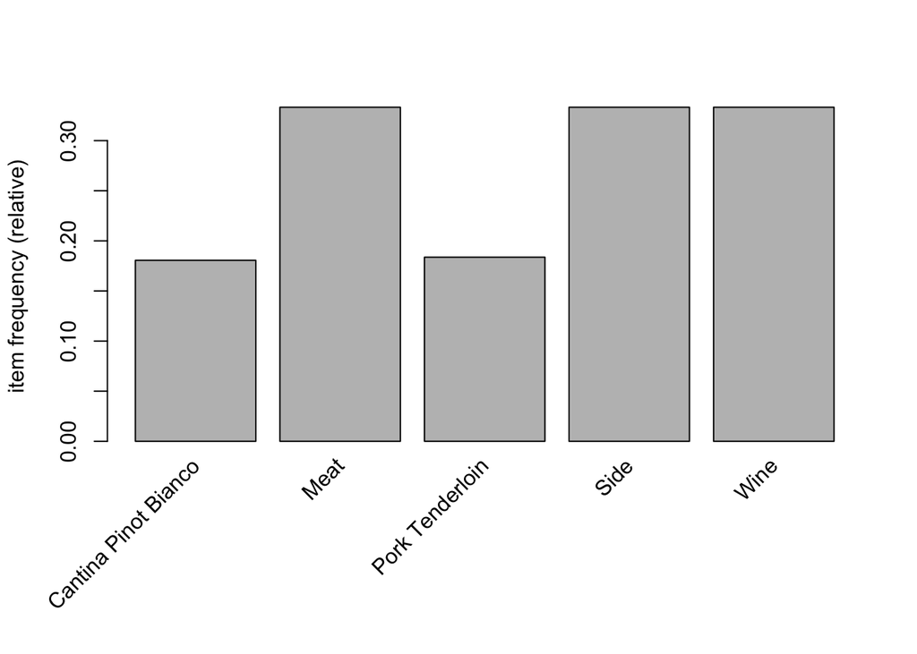

```r
itemFrequencyPlot(menu, support = 0.1)
```

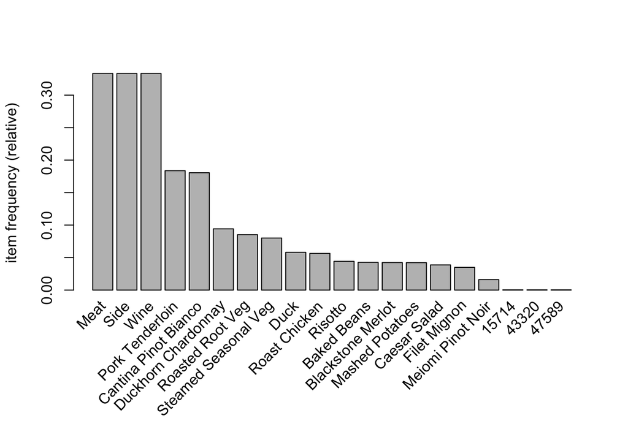

```r
itemFrequencyPlot(menu, topN = 20 )
```

[figure not shown]

```r
image(menu[1:3])
```

#### Learning the association rules from the dataset with default settings

```r
apriori(menu)
```

```
## Apriori
##
## Parameter specification:
##  confidence minval smax arem  aval originalSupport maxtime support minlen
##         0.8    0.1    1 none FALSE            TRUE       5     0.1      1
##  maxlen target   ext
##      10  rules FALSE
##
## Algorithmic control:
##  filter tree heap memopt load sort verbose
##     0.1 TRUE TRUE  FALSE TRUE    2    TRUE
##
## Absolute minimum support count: 2668
##
## set item appearances ...[0 item(s)] done [0.00s].
## set transactions ...[8519 item(s), 26683 transaction(s)] done [0.03s].
## sorting and recoding items ... [5 item(s)] done [0.00s].
## creating transaction tree ... done [0.00s].
## checking subsets of size 1 2 done [0.00s].
## writing ... [2 rule(s)] done [0.00s].
## creating S4 object  ... done [0.00s].
```

```
## set of 2 rules
```

#### Setting the confidence levels and support to learn more rules

```r
rules <- apriori(menu, parameter = list(support = 0.006, confidence = 0.25, minlen = 2))
```

```
## Apriori
##
## Parameter specification:
##  confidence minval smax arem  aval originalSupport maxtime support minlen
##        0.25    0.1    1 none FALSE            TRUE       5   0.006      2
##  maxlen target   ext
##      10  rules FALSE
##
## Algorithmic control:
##  filter tree heap memopt load sort verbose
##     0.1 TRUE TRUE  FALSE TRUE    2    TRUE
##
## Absolute minimum support count: 160
##
## set item appearances ...[0 item(s)] done [0.00s].
## set transactions ...[8519 item(s), 26683 transaction(s)] done [0.02s].
## sorting and recoding items ... [17 item(s)] done [0.00s].
## creating transaction tree ... done [0.00s].
## checking subsets of size 1 2 done [0.00s].
## writing ... [18 rule(s)] done [0.00s].
## creating S4 object  ... done [0.00s].
```

#### Checking out the rules

```r
summary(rules)
```

```
## set of 18 rules
##
## rule length distribution (lhs + rhs):sizes
##  2
## 18
##
##    Min. 1st Qu.  Median    Mean 3rd Qu.    Max.
##       2       2       2       2       2       2
##
## summary of quality measures:
##     support          confidence          lift       count
##  Min.   :0.01612   Min.   :0.2559   Min.   :3   Min.   : 430
##  1st Qu.:0.04245   1st Qu.:1.0000   1st Qu.:3   1st Qu.:1133
##  Median :0.06911   Median :1.0000   Median :3   Median :1844
##  Mean   :0.08577   Mean   :0.8684   Mean   :3   Mean   :2288
##  3rd Qu.:0.09425   3rd Qu.:1.0000   3rd Qu.:3   3rd Qu.:2515
##  Max.   :0.18371   Max.   :1.0000   Max.   :3   Max.   :4902
##
## mining info:
##  data ntransactions support confidence
##  menu         26683   0.006       0.25
```

#### 18 rules were discovered with parameter tweaks

```r
inspect(rules)
```

```
##      lhs                       rhs                    support
## [1]  {Meiomi Pinot Noir}    => {Wine}                 0.01611513
## [2]  {Filet Mignon}         => {Meat}                 0.03500356
## [3]  {Caesar Salad}         => {Side}                 0.03878874
## [4]  {Mashed Potatoes}      => {Side}                 0.04219915
## [5]  {Blackstone Merlot}    => {Wine}                 0.04238654
## [6]  {Baked Beans}          => {Side}                 0.04264888
## [7]  {Risotto}              => {Side}                 0.04429787
## [8]  {Roast Chicken}        => {Meat}                 0.05647791
## [9]  {Duck}                 => {Meat}                 0.05812690
## [10] {Steamed Seasonal Veg} => {Side}                 0.08008845
## [11] {Roasted Root Veg}     => {Side}                 0.08529776
## [12] {Side}                 => {Roasted Root Veg}     0.08529776
## [13] {Duckhorn Chardonnay}  => {Wine}                 0.09425477
## [14] {Wine}                 => {Duckhorn Chardonnay}  0.09425477
```

[output cut: 23 more lines]

#### Looks like they were sorted by ascending support.

#### Inspecting with sort by lift.

```r
inspect(sort(rules, by = "lift"))
```

```
##      lhs                       rhs                    support
## [1]  {Wine}                 => {Cantina Pinot Bianco} 0.18056440
## [2]  {Meat}                 => {Pork Tenderloin}      0.18371248
## [3]  {Meiomi Pinot Noir}    => {Wine}                 0.01611513
## [4]  {Filet Mignon}         => {Meat}                 0.03500356
## [5]  {Caesar Salad}         => {Side}                 0.03878874
## [6]  {Mashed Potatoes}      => {Side}                 0.04219915
## [7]  {Blackstone Merlot}    => {Wine}                 0.04238654
## [8]  {Baked Beans}          => {Side}                 0.04264888
## [9]  {Risotto}              => {Side}                 0.04429787
## [10] {Roast Chicken}        => {Meat}                 0.05647791
## [11] {Duck}                 => {Meat}                 0.05812690
## [12] {Steamed Seasonal Veg} => {Side}                 0.08008845
## [13] {Roasted Root Veg}     => {Side}                 0.08529776
## [14] {Side}                 => {Roasted Root Veg}     0.08529776
```

[output cut: 23 more lines]

#### Find subset of rules for main courses

```r
mains_rules <- subset(rules, items %in% c("Filet Mignon", "Roast Chicken", "Duck", "Pork Tenderloin"))
inspect(mains_rules)
```

```
##     lhs                  rhs               support    confidence lift
## [1] {Filet Mignon}    => {Meat}            0.03500356 1.0000000  3.000112
## [2] {Roast Chicken}   => {Meat}            0.05647791 1.0000000  3.000112
## [3] {Duck}            => {Meat}            0.05812690 1.0000000  3.000112
## [4] {Pork Tenderloin} => {Meat}            0.18371248 1.0000000  3.000112
## [5] {Meat}            => {Pork Tenderloin} 0.18371248 0.5511581  3.000112
##     count
## [1]  934
## [2] 1507
## [3] 1551
## [4] 4902
## [5] 4902
```